# Spring/Summer Chinook parr survival estimates

Michelle A. Briggs<sup>1,✉</sup>, and Ryan N. Kinzer<sup>1,✉</sup>

25 September, 2026

<sup>1</sup> Nez Perce Tribe, Department of Fisheries Resources Management, 14054 Burr Dr., McCall, Idaho, 83638, USA

<sup>✉</sup> Correspondence: Michelle A. Briggs <michelleb@nezperce.org>, Ryan N. Kinzer <ryank@nezperce.org>

### 1 Methods

Survival was estimated for juvenile spring/summer (sp/sum) Chinook salmon tagged in 2025. Chinook salmon parr were tagged with PIT tags in summer and fall of 2025 at nineteen locations in the Snake River Basin. Summer tagging occurred before 1 September 2025; fall tagging occurred on or after 1 September. The number of fish tagged by location and season varied from 14 to 1,499 ( Table 1). Fish were subsequently detected at in-stream PIT tag arrays, at Lower Granite Dam, and at sites downstream of Lower Granite Dam in the Snake and Columbia rivers. Detections occurred at fourteen in-stream PIT tag arrays. Detections at the LC1 and LC2 arrays and at the SC1 and SC2 arrays were pooled due to close spatial proximity and are represented by detection sites LC12 and SC12, respectively. Each array detected between 3 and 1,055 tagged juvenile sp/sum Chinook salmon (Table 2). Detections at Lower Granite Dam (LGR) included detections in the juvenile bypass system and the spillway. Detections at sites downstream of LGR were pooled (detection site “Down”). Detections occurred from July 2025 to August 2026 (Figure 1).

Table 1: The number of juvenile sp/sum Chinook salmon tagged by release site and season in 2025. Release sites are grouped by major population group (MPG).

| Release site | Site name | Tag season | Number of tagged fish |
| --- | --- | --- | --- |
| **Dry Clearwater** |  |  |  |
| AMERR | American River | Fall | 279 |
| AMERR | American River | Summer | 14 |
| CROOKR | Crooked River | Fall | 270 |
| NEWSOC | Newsome Creek | Fall | 200 |
| NEWSOC | Newsome Creek | Summer | 400 |
| REDR | Red River | Fall | 231 |
| REDR | Red River | Summer | 84 |
| **Grande Ronde/Imnaha** |  |  |  |
| BEAR6C | Bear Creek | Summer | 15 |
| HURRIC | Hurricane Creek | Summer | 975 |
| WALLOR | Wallowa River | Summer | 176 |
| **MF Salmon** |  |  |  |
| CAPEHC | Capehorn Creek | Summer | 211 |
| CHAMBC | Chamberlin Creek | Summer | 474 |
| MARSHC | Marsh Creek | Summer | 1346 |
| **SF Salmon** |  |  |  |
| BURNLC | Burnt Log Creek | Summer | 52 |
| GROUSC | Grouse Creek | Summer | 168 |
| JOHNSC | Johnson Creek | Summer | 791 |
| LAKEC | Lake Creek | Summer | 955 |
| SAEFSF | East Fork South Fork Salmon River | Summer | 127 |
| SALRSF | South Fork Salmon River | Summer | 1499 |
| SECESR | Secesh River | Summer | 940 |
| SUMITC | Summit Creek | Summer | 174 |
| **Wet Clearwater** |  |  |  |
| LOLOC | Lolo Creek | Fall | 74 |
| LOLOC | Lolo Creek | Summer | 169 |

Table 2: The number of juvenile sp/sum Chinook salmon detected at instream detection sites during downstream migration. Detections at Down represent detections at all sites downstream of Lower Granite Dam combined. Detections at LC12 represent detections at sites LC1 and LC2 combined, and detections at SC12 represent detections at sites SC1 and SC2 combined. Fish tagged and released at the associated release sites will pass the indicated detection site during downstream migration.

| Detection site | Number of detected fish | Associated release sites |
| --- | --- | --- |
| CRA | 117 | CROOKR |
| Down | 175 | All |
| ESS | 61 | BURNLC, JOHNSC, SAEFSF |
| KRS | 180 | SALRSF |
| LC12 | 15 | LOLOC |
| LGR | 331 | All |
| MAR | 1055 | CAPEHC, MARSHC |
| SC12 | 15 | AMERR, CROOKR, NEWSOC, REDR |
| SC3 | 86 | AMERR, CROOKR, NEWSOC, REDR |
| SC4 | 232 | AMERR, CROOKR, NEWSOC, REDR |
| SFG | 193 | BURNLC, GROUSC, JOHNSC, SAEFSF, SUMITC, LAKEC, SALRSF, SECESR |
| WR1 | 3 | BEAR6C, HURRIC, WALLOR |
| WR2 | 60 | BEAR6C, HURRIC, WALLOR |
| ZEN | 459 | GROUSC, SUMITC, LAKEC, SECESR |

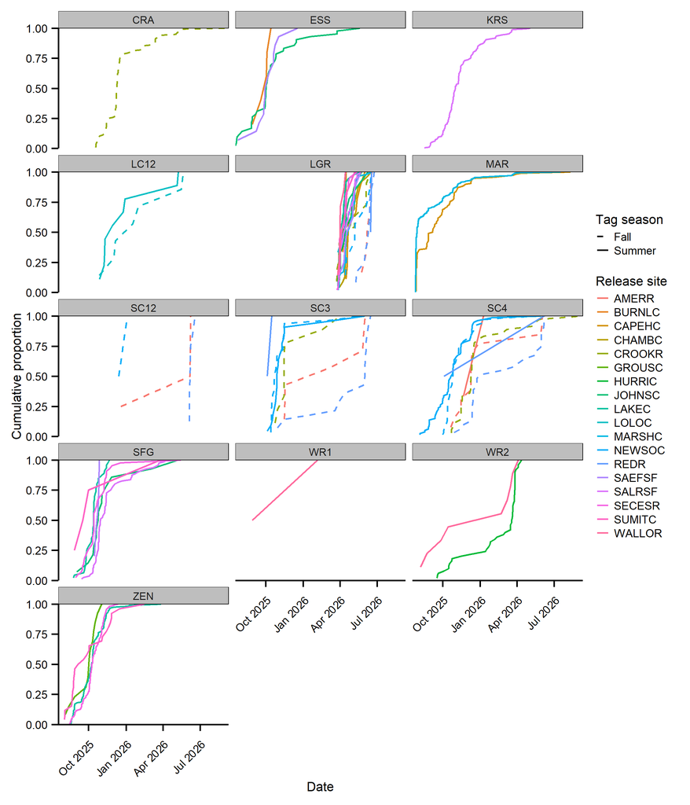

Figure 1: Cumulative emigration timing of juvenile sp/sum Chinook salmon during downstream migration at each in-stream array and at Lower Granite Dam. Each color represents a unique tag group. Solid lines indicate summer-tagged fish, and dashed lines indicate fall-tagged fish.

### 2 Results and discussion

Release groups with low sample sizes tended to have lower precision of reach-specific survival estimates. For example, Burnt Log Creek, Grouse Creek, and Summit Creek had sample sizes of 52, 168, and 174 tagged fish, respectively; each of these release groups had imprecise survival estimates. Estimates of detection probability for release groups with lower sample sizes also showed lower precision (Figure 3, Table 4). The target sample size was a minimum of 300 tagged fish per release group, and the results suggest that reaching the target sample size may improve survival estimates. In addition to low sample sizes, low detection probabilities at some in-stream arrays, such as SFG and SC12, may be reducing the precision associated with reach-specific survival estimates.

To improve survival estimates, future modeling efforts will leverage shared detection sites among release groups by estimating a single detection probability per detection site. This approach will also reduce variability in estimates of detection probability for a single detection site. For example, estimates of detection probability for ZEN varied from 0.135 to 0.670 for different release groups (Table 4), although emigration timing appears to be similar among groups (Figure 1). Using multiple release groups to estimate a single detection probability may improve the precision of model estimates by increasing the sample size associated with downstream detection sites. A similar approach may be used for sites with both summer and fall tag groups. For appropriate reaches and detection sites, a single survival or detection probability will be estimated for both summer- and fall-tagged fish. As with the multiple release group approach, using both summer- and fall-tagged fish in a single model will increase the sample sizes associated with downstream detection and reach-specific survival estimates.

Table 3: Reach-specific estimates of survival for juvenile sp/sum Chinook salmon during downstream migration to Lower Granite Dam.

| Tag season | Interval | From site | To site | Estimate | 95% CI |
| --- | --- | --- | --- | --- | --- |
| **Dry Clearwater** |  |  |  |  |  |
| **NEWSOC** |  |  |  |  |  |
| Summer | 1 | NEWSOC | SC4 | 0.240 | 0.189 - 0.3 |
| Summer | 2 | SC4 | SC3 | 0.701 | 0.011 - 0.998 |
| Summer | 3 | SC3 | SC12 | 0.974 | 0 - 1 |
| Summer | 4 | SC12 | LGR | 0.038 | 0 - 1 |
| Fall | 1 | NEWSOC | SC4 | 0.412 | 0.333 - 0.496 |
| Fall | 2 | SC4 | SC3 | 1.000 | 0 - 1 |
| Fall | 3 | SC3 | SC12 | 1.000 | 0 - 1 |
| Fall | 4 | SC12 | LGR | 0.085 | 0.041 - 0.17 |
| **REDR** |  |  |  |  |  |
| Summer | 1 | REDR | SC4 | 0.062 | 0.02 - 0.177 |
| Summer | 2 | SC4 | SC3 | 1.000 | 0 - 1 |
| Summer | 3 | SC3 | SC12 | 0.406 | 0 - 1 |
| Summer | 4 | SC12 | LGR | 0.951 | 0 - 1 |
| Fall | 1 | REDR | SC4 | 0.329 | 0.22 - 0.461 |
| Fall | 2 | SC4 | SC3 | 1.000 | 0 - 1 |
| Fall | 3 | SC3 | SC12 | 0.438 | 0.159 - 0.764 |
| Fall | 4 | SC12 | LGR | 1.000 | 0 - 1 |
| **AMERR** |  |  |  |  |  |
| Fall | 1 | AMERR | SC4 | 0.202 | 0.076 - 0.439 |
| Fall | 2 | SC4 | SC3 | 0.497 | 0.062 - 0.937 |
| Fall | 3 | SC3 | SC12 | 0.428 | 0.065 - 0.89 |
| Fall | 4 | SC12 | LGR | 0.584 | NaN - NaN |
| **CROOKR** |  |  |  |  |  |
| Fall | 1 | CROOKR | CRA | 0.448 | 0.386 - 0.51 |
| Fall | 2 | CRA | SC4 | 0.657 | 0.406 - 0.843 |
| Fall | 3 | SC4 | SC3 | 1.000 | 0 - 1 |
| Fall | 4 | SC3 | SC12 | 1.000 | 0 - 1 |
| Fall | 5 | SC12 | LGR | 0.999 | 0 - 1 |

[output cut: 57 more lines]

Table 4: Estimates of detection probability for juvenile sp/sum Chinook salmon at in-stream detection sites during downstream migration to Lower Granite Dam. Detection probability was estimated independently for each release group.

| Tag season | Interval | Site | Estimate | 95% CI |
| --- | --- | --- | --- | --- |
| **Dry Clearwater** |  |  |  |  |
| **NEWSOC** |  |  |  |  |
| Summer | 2 | SC4 | 0.833 | 0.631 - 0.936 |
| Summer | 3 | SC3 | 0.327 | 0.042 - 0.842 |
| Summer | 4 | SC12 | 0.015 | 0.001 - 0.254 |
| Summer | 5 | LGR | 0.000 | 0 - 1 |
| Fall | 2 | SC4 | 0.813 | 0.657 - 0.908 |
| Fall | 3 | SC3 | 0.388 | 0.282 - 0.506 |
| Fall | 4 | SC12 | 0.024 | 0.006 - 0.092 |
| Fall | 5 | LGR | 1.000 | 0 - 1 |
| **REDR** |  |  |  |  |
| Summer | 2 | SC4 | 0.382 | 0.069 - 0.837 |
| Summer | 3 | SC3 | 0.382 | 0.069 - 0.837 |
| Summer | 4 | SC12 | 0.000 | 0 - 1 |
| Summer | 5 | LGR | 0.988 | 0 - 1 |
| Fall | 2 | SC4 | 0.407 | 0.253 - 0.583 |
| Fall | 3 | SC3 | 0.184 | 0.101 - 0.313 |
| Fall | 4 | SC12 | 0.210 | 0.074 - 0.469 |
| Fall | 5 | LGR | 0.360 | 0.135 - 0.669 |
| **AMERR** |  |  |  |  |
| Fall | 2 | SC4 | 0.231 | 0.076 - 0.522 |
| Fall | 3 | SC3 | 0.250 | 0.063 - 0.623 |
| Fall | 4 | SC12 | 0.333 | 0.084 - 0.732 |
| Fall | 5 | LGR | 0.857 | NaN - NaN |
| **CROOKR** |  |  |  |  |
| Fall | 2 | CRA | 0.960 | 0.854 - 0.99 |
| Fall | 3 | SC4 | 0.454 | 0.283 - 0.636 |
| Fall | 4 | SC3 | 0.113 | 0.055 - 0.219 |
| Fall | 5 | SC12 | 0.013 | 0.002 - 0.086 |
| Fall | 6 | LGR | 0.139 | 0.067 - 0.267 |

[output cut: 57 more lines]

Table 5: Estimates of cumulative survival probability for juvenile sp/sum Chinook salmon during downstream migration to Lower Granite Dam.

| Tag season | Interval | To site | Estimate | 95% CI |
| --- | --- | --- | --- | --- |
| **Dry Clearwater** |  |  |  |  |
| **NEWSOC** |  |  |  |  |
| Summer | 1 | SC4 | 0.240 | 0.19 - 0.303 |
| Summer | 2 | SC3 | 0.168 | 0.034 - 0.827 |
| Summer | 3 | SC12 | 0.164 | 0.016 - 1 |
| Summer | 4 | LGR | 0.006 | 0 - 1 |
| Fall | 1 | SC4 | 0.412 | 0.337 - 0.503 |
| Fall | 2 | SC3 | 0.412 | 0.337 - 0.503 |
| Fall | 3 | SC12 | 0.412 | 0.334 - 0.509 |
| Fall | 4 | LGR | 0.035 | 0.017 - 0.073 |
| **REDR** |  |  |  |  |
| Summer | 1 | SC4 | 0.062 | 0.021 - 0.188 |
| Summer | 2 | SC3 | 0.062 | 0.021 - 0.188 |
| Summer | 3 | SC12 | 0.025 | 0 - 1 |
| Summer | 4 | LGR | 0.024 | 0 - 1 |
| Fall | 1 | SC4 | 0.329 | 0.227 - 0.477 |
| Fall | 2 | SC3 | 0.329 | 0.227 - 0.477 |
| Fall | 3 | SC12 | 0.144 | 0.068 - 0.307 |
| Fall | 4 | LGR | 0.144 | 0.068 - 0.307 |
| **AMERR** |  |  |  |  |
| Fall | 1 | SC4 | 0.202 | 0.082 - 0.497 |
| Fall | 2 | SC3 | 0.100 | 0.034 - 0.293 |
| Fall | 3 | SC12 | 0.043 | 0.016 - 0.114 |
| Fall | 4 | LGR | 0.025 | 0.025 - 0.025 |
| **CROOKR** |  |  |  |  |
| Fall | 1 | CRA | 0.448 | 0.389 - 0.515 |
| Fall | 2 | SC4 | 0.294 | 0.202 - 0.427 |
| Fall | 3 | SC3 | 0.294 | 0.202 - 0.427 |
| Fall | 4 | SC12 | 0.294 | 0.202 - 0.427 |
| Fall | 5 | LGR | 0.294 | 0.183 - 0.472 |

[output cut: 57 more lines]

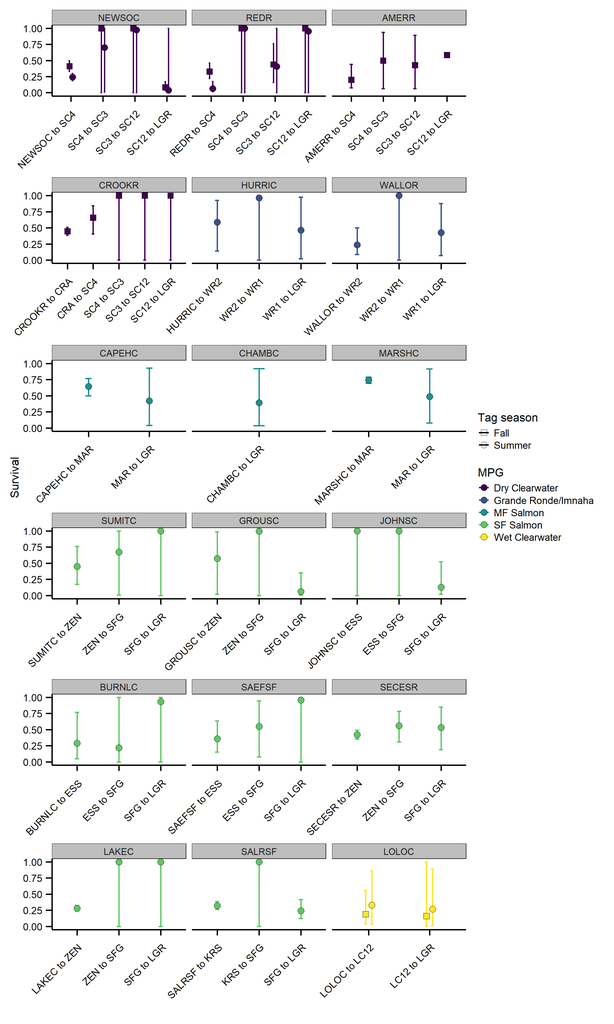

Figure 2: Reach-specific survival estimates for juvenile sp/sum Chinook salmon during downstream migration to Lower Granite Dam. Estimates were produced using the M-array formulation of the CJS model; error bars indicate 95% confidence intervals. The color indicates the major population group.

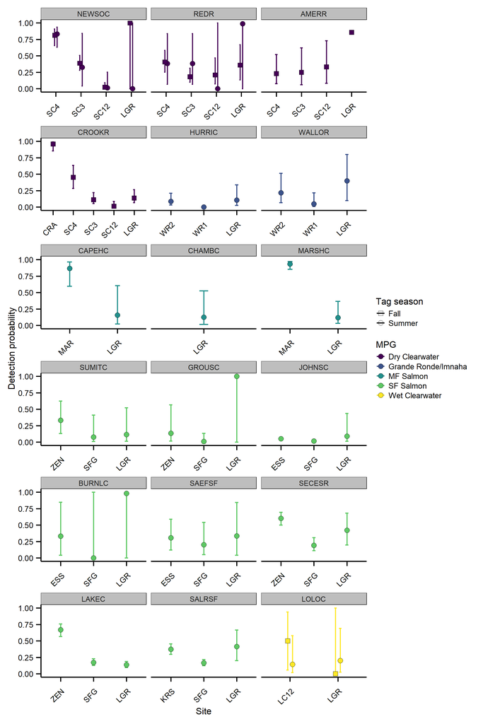

Figure 3: Detection probability estimates for juvenile sp/sum Chinook salmon during downstream migration to Lower Granite Dam by reach. Estimates were produced using the M-array formulation of the CJS model; error bars indicate 95% confidence intervals. The color indicates the major population group.

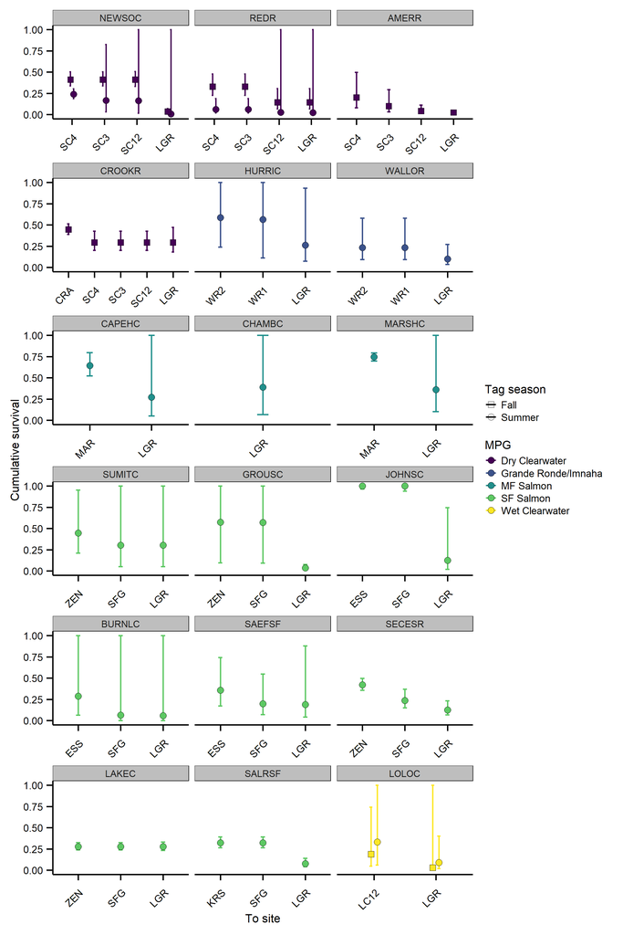

Figure 4: Estimates of cumulative survival for juvenile sp/sum Chinook salmon to Lower Granite Dam by reach. Estimates were produced using the M-array formulation of the CJS model; error bars indicate 95% confidence intervals. The color indicates the major population group.

#### References

Burnham, K. P., D. R. Anderson, G. C. White, C. Brownie, and K. H. Pollock. 1987. Design and analysis methods for fish survival experiments based on release-recapture. American Fisheries Society, Bethesda, Maryland.

Lamb, J. J., B. P. Sandford, S. G. Smith, L. W. Stearman, R. M. Gleason, and A. L. Barenberg. 2026. [Monitoring the migrations of wild snake river spring/summer chinook salmon juveniles: Survival and timing, 2025](https://doi.org/10.25923/vjd7-4b57). Pages P112397, 963299.